# R Notebook

```r
# install packages(c("readxl", "dplyr", "lubridate"))
library(readxl)
library(dplyr)
library(lubridate) ## package to deal with dates
```

Read the data in

```r
beer <- read_excel(path = "../data-raw/beer-eng.xlsx")

head(beer)
```

| id | date | hhsize | klm | education | region | place_type | count |
| --- | --- | --- | --- | --- | --- | --- | --- |
| 000208 | 20101105 | 3 Persons | Village | Profession Or Secondary | Podkarpackie | Discount | 1 |
| 000208 | 20101106 | 3 Persons | Village | Profession Or Secondary | Podkarpackie | Retail networks | 2 |
| 000208 | 20101122 | 3 Persons | Village | Profession Or Secondary | Podkarpackie | Retail networks | 1 |
| 000208 | 20101206 | 3 Persons | Village | Profession Or Secondary | Podkarpackie | Discount | 1 |
| 000208 | 20101212 | 3 Persons | Village | Profession Or Secondary | Podkarpackie | Retail networks | 2 |
| 000208 | 20101220 | 3 Persons | Village | Profession Or Secondary | Podkarpackie | Discount | 8 |

Formating of dates

%Y – YYYY (eg. 2010) %m – MM (eg. 11) %d – DD (eg. 02)

```r
## extract dates from the dataset by using as.Date function
beer <- beer %>%
  mutate(date = as.character(date),
         date = as.Date(date, format = "%Y%m%d"))

### extract year from date variable using lubridate::year
beer <- beer %>% mutate(year = year(date) - 2009,
                        week_day = wday(date, week_start = 1))

head(beer)
```

| id | date | hhsize | klm | education | region | place_type | count | year | week_day |
| --- | --- | --- | --- | --- | --- | --- | --- | --- | --- |
| 000208 | 2010-11-05 | 3 Persons | Village | Profession Or Secondary | Podkarpackie | Discount | 1 | 1 | 5 |
| 000208 | 2010-11-06 | 3 Persons | Village | Profession Or Secondary | Podkarpackie | Retail networks | 2 | 1 | 6 |
| 000208 | 2010-11-22 | 3 Persons | Village | Profession Or Secondary | Podkarpackie | Retail networks | 1 | 1 | 1 |
| 000208 | 2010-12-06 | 3 Persons | Village | Profession Or Secondary | Podkarpackie | Discount | 1 | 1 | 1 |
| 000208 | 2010-12-12 | 3 Persons | Village | Profession Or Secondary | Podkarpackie | Retail networks | 2 | 1 | 7 |
| 000208 | 2010-12-20 | 3 Persons | Village | Profession Or Secondary | Podkarpackie | Discount | 8 | 1 | 1 |

Example usage of `lubridate::ymd` function

```r
ymd(c("2018-01-02", "2018.01.02", "2018/01/02"))
```

```
[1] "2018-01-02" "2018-01-02" "2018-01-02"
```

Check the size – number of transactions (assuming that on given day there was only one transaction)

```r
dim(beer)
```

```
[1] 80472    10
```

How many hh we have in our data and how many transactions they made

```r
beer %>% count(id, sort = TRUE) ## count ant sort
```

| id | n |
| --- | --- |
| 984552 | 309 |
| 096465 | 301 |
| 041654 | 259 |
| 098027 | 257 |
| 882139 | 256 |
| 032884 | 252 |
| 021193 | 241 |
| 082948 | 241 |
| 962062 | 232 |
| 091434 | 229 |

[output cut: 990 more lines]

```r
beer %>% count(id, sort = FALSE)  ## count without sorting
```

| id | n |
| --- | --- |
| 000208 | 14 |
| 000212 | 14 |
| 000278 | 31 |
| 000386 | 5 |
| 000496 | 64 |
| 000522 | 18 |
| 000537 | 4 |
| 000589 | 1 |
| 000605 | 2 |
| 000618 | 5 |

[output cut: 990 more lines]

```r
beer %>% count(id, sort = TRUE) %>% filter(n == 1) ## count and filter households with only one transaction
```

| id | n |
| --- | --- |
| 000589 | 1 |
| 000728 | 1 |
| 001691 | 1 |
| 001978 | 1 |
| 002114 | 1 |
| 002484 | 1 |
| 002801 | 1 |
| 003191 | 1 |
| 010748 | 1 |
| 013275 | 1 |

[output cut: 557 more lines]

Let’s see the distribution of count variable (number of beers bought)

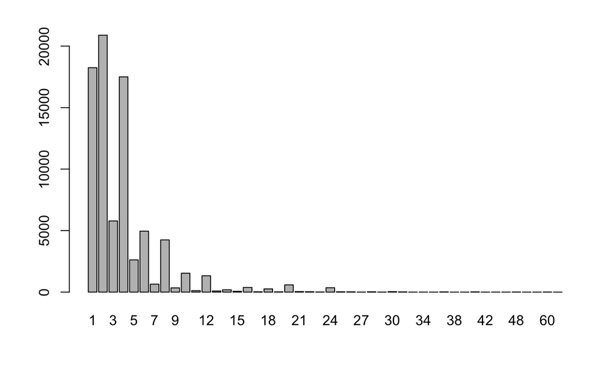

```r
barplot(table(beer$count))
```

Let’s built a simple linear regression

lm - linear model formula - writting down the model

IN R: dependent ~ independent | y ~ x1 + x2 + x3 … IN SAS/SPSS: y = x1 x2 x2

$$y_i = \beta_0 + \epsilon_i, \quad \epsilon_i \sim N(0, \sigma)$$

Fit the linear model

```r
model1 <- lm(formula = count ~ 1, data = beer)
model1
```

```
Call:
lm(formula = count ~ 1, data = beer)

Coefficients:
(Intercept)
      3.846
```

```r
summary(model1)
```

```
Call:
lm(formula = count ~ 1, data = beer)

Residuals:
   Min     1Q Median     3Q    Max
-2.846 -1.846 -0.846  0.154 62.154

Coefficients:
            Estimate Std. Error t value Pr(>|t|)
(Intercept)  3.84602    0.01333   288.5   <2e-16 ***
---
Signif. codes:  0 ‘***’ 0.001 ‘**’ 0.01 ‘*’ 0.05 ‘.’ 0.1 ‘ ’ 1

Residual standard error: 3.781 on 80471 degrees of freedom
```

Include into the model variable year

$$y_i = \beta_0 + \beta_1 \times year + \epsilon_i, \quad \epsilon_i \sim N(0, \sigma)$$
and include categorical variable

$$y_i = \beta_0 + \beta_1 \times year + \beta_2 \times (wday=2) + \beta_3 * (wday=3) + ... + \epsilon_i, \quad \epsilon_i \sim N(0, \sigma)$$

Fit the models in R

```r
model2 <- lm(formula = count ~ year, data = beer)
model3 <- lm(formula = count ~ year + factor(week_day), data = beer)
summary(model3)
```

```
Call:
lm(formula = count ~ year + factor(week_day), data = beer)

Residuals:
   Min     1Q Median     3Q    Max
-3.159 -2.159 -1.094  0.433 61.906

Coefficients:
                  Estimate Std. Error t value Pr(>|t|)
(Intercept)        3.40406    0.06128  55.553  < 2e-16 ***
year               0.16292    0.02835   5.746 9.15e-09 ***
factor(week_day)2 -0.09330    0.05294  -1.762    0.078 .
factor(week_day)3 -0.03257    0.05159  -0.631    0.528
factor(week_day)4  0.11473    0.05187   2.212    0.027 *
factor(week_day)5  0.36373    0.05000   7.274 3.52e-13 ***
factor(week_day)6  0.42883    0.04878   8.791  < 2e-16 ***
factor(week_day)7  0.27962    0.05885   4.751 2.03e-06 ***
---
Signif. codes:  0 ‘***’ 0.001 ‘**’ 0.01 ‘*’ 0.05 ‘.’ 0.1 ‘ ’ 1

Residual standard error: 3.775 on 80464 degrees of freedom
Multiple R-squared:  0.003185,  Adjusted R-squared:  0.003098
F-statistic: 36.73 on 7 and 80464 DF,  p-value: < 2.2e-16
```

numerical scale - number of beers, salary nominal scale - region, week day

Let’s declare categorical variable in the dataset

```r
beer <- beer %>% mutate(week_day = factor(week_day)) ## declare as factor / categorical variable
beer <- beer %>% mutate(week_day = relevel(week_day, ref = "5")) ## change the reference level

model3 <- lm(formula = count ~ year + week_day, data = beer)
summary(model3)
```

```
Call:
lm(formula = count ~ year + week_day, data = beer)

Residuals:
   Min     1Q Median     3Q    Max
-3.159 -2.159 -1.094  0.433 61.906

Coefficients:
            Estimate Std. Error t value Pr(>|t|)
(Intercept)  3.76779    0.05725  65.815  < 2e-16 ***
year         0.16292    0.02835   5.746 9.15e-09 ***
week_day1   -0.36373    0.05000  -7.274 3.52e-13 ***
week_day2   -0.45703    0.04870  -9.385  < 2e-16 ***
week_day3   -0.39629    0.04722  -8.392  < 2e-16 ***
week_day4   -0.24900    0.04752  -5.240 1.61e-07 ***
week_day6    0.06510    0.04414   1.475    0.140
week_day7   -0.08411    0.05506  -1.528    0.127
---
Signif. codes:  0 ‘***’ 0.001 ‘**’ 0.01 ‘*’ 0.05 ‘.’ 0.1 ‘ ’ 1

Residual standard error: 3.775 on 80464 degrees of freedom
Multiple R-squared:  0.003185,  Adjusted R-squared:  0.003098
F-statistic: 36.73 on 7 and 80464 DF,  p-value: < 2.2e-16
```

Standard asumptions of linear regression:

- linear relationship – we don’t know, we need to investigate
- normally distributed residuals N(0, sigma), constant variance (homoscedasticity) – not met, standard errors will be underestimated
- continous Y variable – count data – linear regression is a bad choice, we should go for generalized linear models (GLM)
- observations are not correlated / independent from each other

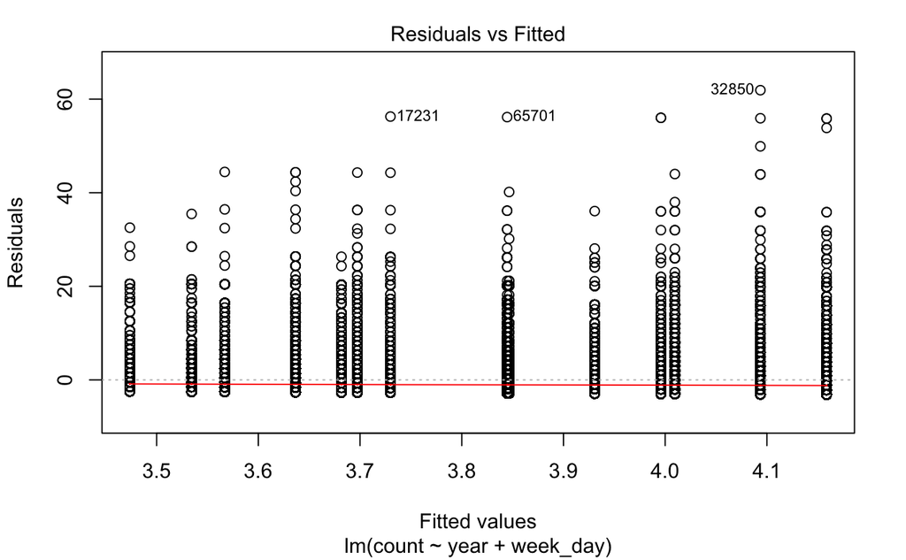

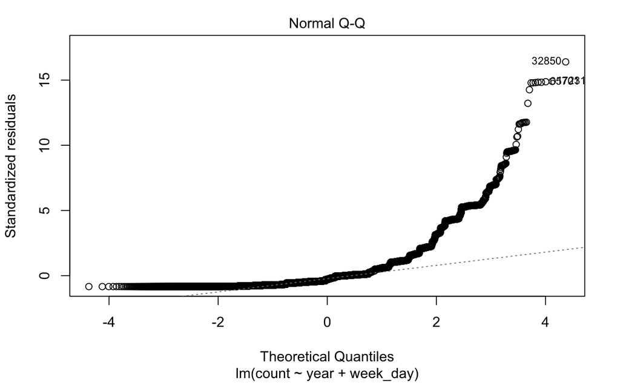

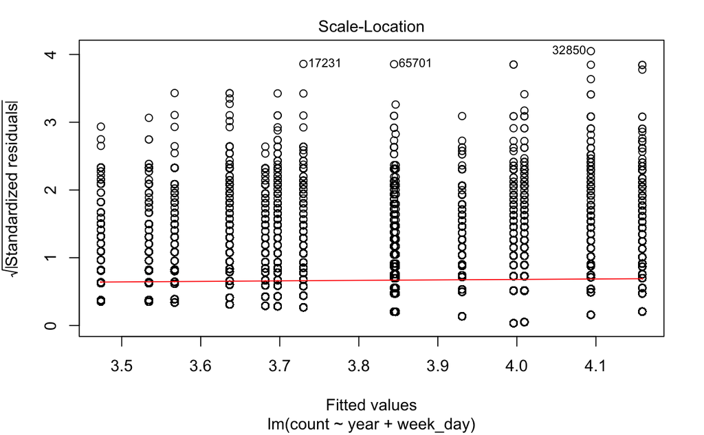

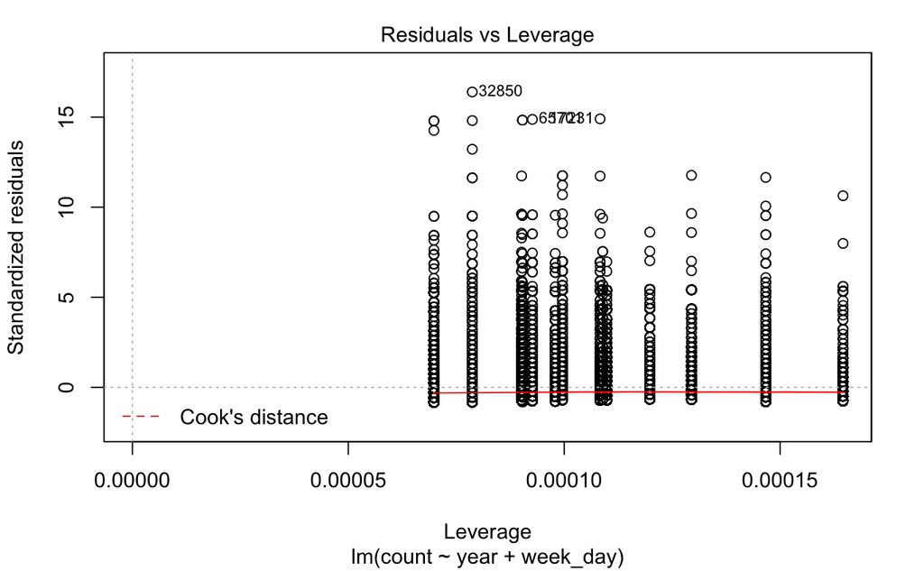